# Tanzanian Water Pumps

### PRELIMINARY ACTIVITIES

Libraries import:

```r
# For importing, pre-process and transform data
library(data.table)
library(dplyr)
library(tidylog)
library(plyr)
library(lubridate)
library(forcats)
library(tibble)

# For visualizing data
library(ggplot2)
library(ggthemes)
library(kableExtra)

# For data exploration
library(autoEDA)
library(gtsummary)
library(purrr)
library(DataExplorer)

# For modeling
library(randomForest)
library(caret)
library(Boruta)
```

Data import, converting all characters to factors. I decided to use URL to import input data in order to make my workflow reproducible on other local machines:

```r
# Import independent variables training set

Training_url <- "http://s3.amazonaws.com/drivendata/data/7/public/4910797b-ee55-40a7-8668-10efd5c1b960.csv"

Training_set_ind_vars <- fread(Training_url, stringsAsFactors = T)

# Import target variable training set

train_labels_url <- "http://s3.amazonaws.com/drivendata/data/7/public/0bf8bc6e-30d0-4c50-956a-603fc693d966.csv"

Training_set_target_var <- fread(train_labels_url, stringsAsFactors = T)

# Import test set

test_set_url <- "http://s3.amazonaws.com/drivendata/data/7/public/702ddfc5-68cd-4d1d-a0de-f5f566f76d91.csv"

Test_set <- fread(test_set_url, stringsAsFactors = T)

# Removing redundant objects
rm(Training_url,train_labels_url,test_set_url)
```

### DATA PRE-PROCESSING

Joining independent and dependent variables in a whole training set:

```r
# Create complete training set
Training_set_complete <- Training_set_ind_vars %>%
  left_join(Training_set_target_var)
```

```
## left_join: added one column (status_group)
```

```
##            > rows only in x        0
```

```
##            > rows only in y  (     0)
```

```
##            > matched rows     59,400
```

```
##            >                 ========
```

```
##            > rows total       59,400
```

```r
# Remove no more useful tables
rm(Training_set_target_var)
rm(Training_set_ind_vars)
```

Verifying all labeled records:

```r
sum(is.na(Training_set_complete$status_group))
```

```
## [1] 0
```

```r
sum(Training_set_complete[,status_group==""])
```

```
## [1] 0
```

```r
# all records are properly labeled
```

Verifying no duplicated records exist within training set (obviously excluding “id”):

```r
nrow(unique(Training_set_complete[,-"id"]))
```

```
## [1] 59364
```

```r
# so there exist 36 records (59.400-59.364) with all features equal except for "id"
```

Isolating an example of duplicate record:

```r
# Creating a table including only distinct records
dups <- distinct(Training_set_complete[,-"id"])

# Bringing unique key to just created table
dups <- dups %>%
  left_join(Training_set_complete)

# Getting not unique records by joining for all fields but "id"
dups %>%
  dplyr::group_by(amount_tsh, date_recorded, funder, gps_height, installer, longitude, latitude, wpt_name, num_private, basin, subvillage, region, region_code, district_code, lga, ward, population, public_meeting, recorded_by, scheme_management, scheme_name, permit, construction_year, extraction_type, extraction_type_group, extraction_type_class, management, management_group, payment, payment_type, water_quality, quality_group, quantity, quantity_group, source, source_type, source_class, waterpoint_type, waterpoint_type_group, status_group) %>%
  dplyr::summarise(count=n()) %>%
  dplyr::filter(count>1) %>%
  dplyr::arrange((desc(count))) %>%
  kbl() %>%
  kable_paper() %>%
  kable_styling(bootstrap_options = c("striped", "hover", "condensed"))
```

| amount_tsh | date_recorded | funder | gps_height | installer | longitude | latitude | wpt_name | num_private | basin | subvillage | region | region_code | district_code | lga | ward | population | public_meeting | recorded_by | scheme_management | scheme_name | permit | construction_year | extraction_type | extraction_type_group | extraction_type_class | management | management_group | payment | payment_type | … |
| --- | --- | --- | --- | --- | --- | --- | --- | --- | --- | --- | --- | --- | --- | --- | --- | --- | --- | --- | --- | --- | --- | --- | --- | --- | --- | --- | --- | --- | --- | --- |
| 0 | 2011-07-18 | Government Of Tanzania | 0 | Government | 0.00000 | 0.000000 | Hospital | 0 | Lake Victoria | Nyanza | Mwanza | 19 | 6 | Geita | Kalangalala | 0 | TRUE | GeoData Consultants Ltd | VWC | Kalangalala | TRUE | 0 | submersible | submersible | submersible | vwc | user-group | never pay | never pay | … |
| 0 | 2011-07-27 | Hesawa | 0 | DWE | 0.00000 | 0.000000 | Bombani | 0 | Lake Victoria | Kabulabunyasi | Mwanza | 19 | 6 | Geita | Lubanga | 0 | TRUE | GeoData Consultants Ltd | VWC |  | TRUE | 0 | nira/tanira | nira/tanira | handpump | vwc | user-group | never pay | never pay | … |
| 0 | 2011-07-13 | He | 0 | HE | 31.61953 | -1.793342 | Kahindu | 0 | Lake Victoria | Ikondoa | Kagera | 18 | 3 | Muleba | Ikondo | 0 | TRUE | GeoData Consultants Ltd | VWC |  | TRUE | 0 | gravity | gravity | gravity | vwc | user-group | never pay | never pay | … |
| 0 | 2011-07-18 | Government Of Tanzania | 0 | Government | 0.00000 | 0.000000 | Nersing College | 0 | Lake Victoria | Nyanza | Mwanza | 19 | 6 | Geita | Kalangalala | 0 | TRUE | GeoData Consultants Ltd | VWC | Borehole | TRUE | 0 | afridev | afridev | handpump | vwc | user-group | never pay | never pay | … |
| 0 | 2011-07-19 | Government Of Tanzania | 0 | Government | 0.00000 | 0.000000 | K/Secondary | 0 | Lake Victoria | Kisese | Mwanza | 19 | 6 | Geita | Kalangalala | 0 | TRUE | GeoData Consultants Ltd | VWC | 14 Kambarage | TRUE | 0 | submersible | submersible | submersible | vwc | user-group | never pay | never pay | … |
| 0 | 2011-07-19 | Government Of Tanzania | 0 | Government | 0.00000 | 0.000000 | Mulangila | 0 | Lake Victoria | 14Kambalage | Mwanza | 19 | 6 | Geita | Kalangalala | 0 | TRUE | GeoData Consultants Ltd | VWC | 14 Kambarage | TRUE | 0 | submersible | submersible | submersible | vwc | user-group | pay per bucket | per bucket | … |
| 0 | 2011-07-19 | Plan International | 0 | Plan Internationa | 0.00000 | 0.000000 | Elimu Maalum | 0 | Lake Victoria | Mbugani | Mwanza | 19 | 6 | Geita | Kalangalala | 0 | TRUE | GeoData Consultants Ltd | VWC | Nyankumbu | TRUE | 0 | submersible | submersible | submersible | vwc | user-group | never pay | never pay | … |
| 0 | 2011-07-26 | Hesawa | 0 | DWE | 0.00000 | 0.000000 | Bombani | 0 | Lake Victoria | Isadukilo | Mwanza | 19 | 6 | Geita | Lubanga | 0 | TRUE | GeoData Consultants Ltd | VWC |  | TRUE | 0 | nira/tanira | nira/tanira | handpump | vwc | user-group | never pay | never pay | … |
| 0 | 2011-07-28 | Government Of Tanzania | 0 | Government | 0.00000 | 0.000000 | Mahakama | 0 | Lake Victoria | Nyampa A | Mwanza | 19 | 6 | Geita | Kasamwa | 0 | TRUE | GeoData Consultants Ltd | VWC | Kasamwa | TRUE | 0 | ksb | submersible | submersible | vwc | user-group | unknown | unknown | … |
| 0 | 2011-08-02 | Hesawa | 0 | Hesawa | 0.00000 | 0.000000 | Nyanza | 0 | Lake Victoria | Mjini | Mwanza | 19 | 6 | Geita | Nyang’hwale | 0 | TRUE | GeoData Consultants Ltd | VWC |  | TRUE | 0 | other | other | other | vwc | user-group | unknown | unknown | … |
| 0 | 2011-08-06 | Government Of Tanzania | 0 | Government | 0.00000 | 0.000000 | Bombani | 0 | Lake Victoria | Nyamtukuza | Mwanza | 19 | 6 | Geita | Kakora | 0 | TRUE | GeoData Consultants Ltd | VWC | Nyamtukuza | TRUE | 0 | ksb | submersible | submersible | vwc | user-group | unknown | unknown | … |
| 0 | 2012-10-25 | Dwsp | 0 | DWE | 0.00000 | 0.000000 | Igunanilo | 0 | Lake Victoria | Ng’Esha | Mwanza | 17 | 1 | Magu | Nkungulu | 0 | NA | GeoData Consultants Ltd | WUG |  | FALSE | 0 | nira/tanira | nira/tanira | handpump | wug | user-group | unknown | unknown | … |
| 0 | 2012-10-25 | Dwsp | 0 | DWE | 0.00000 | 0.000000 | Mwamusobi | 0 | Lake Victoria | Madukani | Mwanza | 17 | 1 | Magu | Nkungulu | 0 | NA | GeoData Consultants Ltd | WUG |  | FALSE | 0 | nira/tanira | nira/tanira | handpump | wug | user-group | unknown | unknown | … |
| 0 | 2012-10-25 | Dwsp | 0 | DWE | 0.00000 | 0.000000 | Umoja | 0 | Lake Victoria | Ngesha | Mwanza | 17 | 1 | Magu | Nkungulu | 0 | NA | GeoData Consultants Ltd | WUG |  | FALSE | 0 | nira/tanira | nira/tanira | handpump | wug | user-group | unknown | unknown | … |
| 0 | 2012-10-25 | Dwsp | 0 | DWE | 0.00000 | 0.000000 | Umoja Wa Vijana | 0 | Lake Victoria | Nyambuli | Mwanza | 17 | 1 | Magu | Nkungulu | 0 | NA | GeoData Consultants Ltd | WUG |  | FALSE | 0 | nira/tanira | nira/tanira | handpump | wug | user-group | unknown | unknown | … |
| 0 | 2012-10-25 | Dwsp | 0 | DWE | 0.00000 | 0.000000 | Wazazi | 0 | Lake Victoria | Madukani | Mwanza | 17 | 1 | Magu | Nkungulu | 0 | NA | GeoData Consultants Ltd | WUG |  | FALSE | 0 | swn 80 | swn 80 | handpump | wug | user-group | unknown | unknown | … |
| 0 | 2012-10-25 | Holland | 0 | HOLLAND | 0.00000 | 0.000000 | none | 0 | Lake Victoria | Ngara Shuleni | Mwanza | 17 | 1 | Magu | Nkungulu | 0 | NA | GeoData Consultants Ltd | WUG |  | FALSE | 0 | swn 80 | swn 80 | handpump | wug | user-group | unknown | unknown | … |
| 0 | 2012-10-26 | Holland | 0 | HOLLAND | 0.00000 | 0.000000 | Jamii | 0 | Lake Victoria | Habare | Mwanza | 17 | 1 | Magu | Nkungulu | 0 | NA | GeoData Consultants Ltd | WUG |  | FALSE | 0 | swn 80 | swn 80 | handpump | wug | user-group | unknown | unknown | … |
| 0 | 2012-10-26 | Holland | 0 | HOLLAND | 0.00000 | 0.000000 | Jamii | 0 | Lake Victoria | Ngara Shuleni | Mwanza | 17 | 1 | Magu | Nkungulu | 0 | NA | GeoData Consultants Ltd | WUG |  | FALSE | 0 | other | other | other | wug | user-group | unknown | unknown | … |
| 0 | 2012-10-26 | Lwi | 0 | LWI | 0.00000 | 0.000000 | Kwa Mdo | 0 | Lake Victoria | Ng’Esha | Mwanza | 17 | 1 | Magu | Nkungulu | 0 | NA | GeoData Consultants Ltd | WUG |  | FALSE | 0 | india mark iii | india mark iii | handpump | wug | user-group | unknown | unknown | … |
| 0 | 2012-10-26 | Lwi | 0 | LWI | 0.00000 | 0.000000 | Msituni | 0 | Lake Victoria | Nyamiselia | Mwanza | 17 | 1 | Magu | Nkungulu | 0 | NA | GeoData Consultants Ltd | WUG |  | FALSE | 0 | india mark ii | india mark ii | handpump | wug | user-group | unknown | unknown | … |
| 0 | 2012-10-26 | Lwi | 0 | LWI | 0.00000 | 0.000000 | Mwakuzuka | 0 | Lake Victoria | Mwakuzuka | Mwanza | 17 | 1 | Magu | Nkungulu | 0 | NA | GeoData Consultants Ltd | WUG |  | FALSE | 0 | india mark ii | india mark ii | handpump | wug | user-group | unknown | unknown | … |
| 0 | 2012-10-26 | Rwsp | 0 | DWE | 0.00000 | 0.000000 | Sanjo | 0 | Lake Victoria | Madukani | Mwanza | 17 | 1 | Magu | Nkungulu | 0 | NA | GeoData Consultants Ltd | WUG |  | FALSE | 0 | swn 80 | swn 80 | handpump | wug | user-group | unknown | unknown | … |
| 0 | 2012-11-04 | Government Of Tanzania | 0 | RWE | 0.00000 | 0.000000 | School | 0 | Lake Victoria | Shuleni | Mwanza | 19 | 2 | Magu | Mkula | 0 | TRUE | GeoData Consultants Ltd | VWC | Kalemela Water Supply | TRUE | 0 | gravity | gravity | gravity | vwc | user-group | never pay | never pay | … |
| 0 | 2013-01-20 | Wvt | 0 | WVT | 0.00000 | 0.000000 | Shule Ya Msingi Mwanunui | 0 | Lake Victoria | Ing’Ong’O | Shinyanga | 17 | 1 | Bariadi | Nkoma | 0 | TRUE | GeoData Consultants Ltd | Parastatal |  | FALSE | 0 | gravity | gravity | gravity | parastatal | parastatal | never pay | never pay | … |
| 0 | 2013-01-29 | Dwsp | 0 | DWE | 0.00000 | 0.000000 | Isangijo | 0 | Lake Victoria | Nyamisagusa B | Mwanza | 17 | 1 | Magu | Nkungulu | 0 | NA | GeoData Consultants Ltd | WUG |  | FALSE | 0 | swn 80 | swn 80 | handpump | wug | user-group | unknown | unknown | … |
| 0 | 2013-01-30 | Wvt | 0 | WVT | 0.00000 | 0.000000 | Wvt Tanzania | 0 | Lake Victoria | Ilula | Shinyanga | 17 | 1 | Bariadi | Chinamili | 0 | FALSE | GeoData Consultants Ltd | Parastatal |  | FALSE | 0 | gravity | gravity | gravity | parastatal | parastatal | other | other | … |
| 0 | 2013-02-16 | Dwsp | 0 | DWE | 0.00000 | 0.000000 | Igolola | 0 | Lake Victoria | Busumagu | Mwanza | 17 | 1 | Magu | Nkungulu | 0 | NA | GeoData Consultants Ltd | WUG |  | FALSE | 0 | nira/tanira | nira/tanira | handpump | wug | user-group | unknown | unknown | … |
| 0 | 2013-02-16 | Dwsp | 0 | DWE | 0.00000 | 0.000000 | Mwamahonza | 0 | Lake Victoria | Mwamahala | Mwanza | 17 | 1 | Magu | Nkungulu | 0 | NA | GeoData Consultants Ltd | WUG |  | FALSE | 0 | nira/tanira | nira/tanira | handpump | wug | user-group | unknown | unknown | … |
| 0 | 2013-02-16 | Dwsp | 0 | DWE | 0.00000 | 0.000000 | Sango | 0 | Lake Victoria | Nduhu | Mwanza | 17 | 1 | Magu | Nkungulu | 0 | NA | GeoData Consultants Ltd | WUG |  | FALSE | 0 | nira/tanira | nira/tanira | handpump | wug | user-group | unknown | unknown | … |
| 0 | 2013-02-16 | Dwsp | 0 | DWE | 0.00000 | 0.000000 | Serengeti | 0 | Lake Victoria | Madukani | Mwanza | 17 | 1 | Magu | Nkungulu | 0 | NA | GeoData Consultants Ltd | WUG |  | FALSE | 0 | other | other | other | wug | user-group | unknown | unknown | … |
| 0 | 2013-02-16 | Pmo | 0 | DWE | 0.00000 | 0.000000 | Muungano | 0 | Lake Victoria | Madukani | Mwanza | 17 | 1 | Magu | Nkungulu | 0 | NA | GeoData Consultants Ltd | WUG |  | FALSE | 0 | nira/tanira | nira/tanira | handpump | wug | user-group | unknown | unknown | … |
| 0 | 2013-02-16 | Rwssp | 0 | DWE | 0.00000 | 0.000000 | Muungano | 0 | Lake Victoria | Nyamisagusa A | Mwanza | 17 | 1 | Magu | Nkungulu | 0 | NA | GeoData Consultants Ltd | WUG |  | FALSE | 0 | swn 80 | swn 80 | handpump | wug | user-group | unknown | unknown | … |
| 0 | 2013-02-16 | Rwssp | 0 | DWE | 0.00000 | 0.000000 | none | 0 | Lake Victoria | Nyamisagusa A | Mwanza | 17 | 1 | Magu | Nkungulu | 0 | NA | GeoData Consultants Ltd | WUG |  | FALSE | 0 | swn 80 | swn 80 | handpump | wug | user-group | unknown | unknown | … |

```r
# So these are duplicated records that should be treaten
```

Displaying a case of duplicate records:

```r
Training_set_complete %>%
  filter(id %in% c("68204", "28134", "7900"))
```

```
## filter: removed 59,397 rows (>99%), 3 rows remaining
```

| id | amount_tsh | date_recorded | funder | gps_height | installer | longitude | latitude | wpt_name | num_private | basin | subvillage | region | region_code | district_code | lga | ward | population | public_meeting | recorded_by | scheme_management | scheme_name | permit | construction_year | extraction_type | extraction_type_group | extraction_type_class | management | management_group | payment | … |
| --- | --- | --- | --- | --- | --- | --- | --- | --- | --- | --- | --- | --- | --- | --- | --- | --- | --- | --- | --- | --- | --- | --- | --- | --- | --- | --- | --- | --- | --- | --- |
| 7900 | 0 | 2011-07-18 | Government Of Tanzania | 0 | Government | 0 | -2e-08 | Hospital | 0 | Lake Victoria | Nyanza | Mwanza | 19 | 6 | Geita | Kalangalala | 0 | TRUE | GeoData Consultants Ltd | VWC | Kalangalala | TRUE | 0 | submersible | submersible | submersible | vwc | user-group | never pay | … |
| 68204 | 0 | 2011-07-18 | Government Of Tanzania | 0 | Government | 0 | -2e-08 | Hospital | 0 | Lake Victoria | Nyanza | Mwanza | 19 | 6 | Geita | Kalangalala | 0 | TRUE | GeoData Consultants Ltd | VWC | Kalangalala | TRUE | 0 | submersible | submersible | submersible | vwc | user-group | never pay | … |
| 28134 | 0 | 2011-07-18 | Government Of Tanzania | 0 | Government | 0 | -2e-08 | Hospital | 0 | Lake Victoria | Nyanza | Mwanza | 19 | 6 | Geita | Kalangalala | 0 | TRUE | GeoData Consultants Ltd | VWC | Kalangalala | TRUE | 0 | submersible | submersible | submersible | vwc | user-group | never pay | … |

```r
# we get 3 records

# let's apply a distinct (removing "id")
Training_set_complete %>%
  filter(id %in% c("68204", "28134", "7900")) %>%
  select(-"id") %>%
  distinct() %>%
  kbl() %>%
  kable_paper() %>%
  kable_styling(bootstrap_options = c("hover", "condensed"))
```

```
## filter: removed 59,397 rows (>99%), 3 rows remaining
```

```
## distinct: removed 2 rows (67%), one row remaining
```

| amount_tsh | date_recorded | funder | gps_height | installer | longitude | latitude | wpt_name | num_private | basin | subvillage | region | region_code | district_code | lga | ward | population | public_meeting | recorded_by | scheme_management | scheme_name | permit | construction_year | extraction_type | extraction_type_group | extraction_type_class | management | management_group | payment | payment_type | … |
| --- | --- | --- | --- | --- | --- | --- | --- | --- | --- | --- | --- | --- | --- | --- | --- | --- | --- | --- | --- | --- | --- | --- | --- | --- | --- | --- | --- | --- | --- | --- |
| 0 | 2011-07-18 | Government Of Tanzania | 0 | Government | 0 | 0 | Hospital | 0 | Lake Victoria | Nyanza | Mwanza | 19 | 6 | Geita | Kalangalala | 0 | TRUE | GeoData Consultants Ltd | VWC | Kalangalala | TRUE | 0 | submersible | submersible | submersible | vwc | user-group | never pay | never pay | … |

```r
# in fact we get only one observation, so all features are equal
```

If this were a real assignment by one of our Client, I will take time to help them investigate which was the issue related to these cases (maybe an issue of data collection/data quality or maybe we have extracted a subset of all available features and we are not able to display the feature able to distinguish between these three records).

For the sake of this exercise, I will simply consider this a data quality issue and I will remove duplicated records from training set:

```r
# Exluding "id"
Training_and_test_set <- unique(Training_set_complete[,-"id"])

# Creating a join to bring back "id" taking only first occurrence as "id"
Training_and_test_set <- join(Training_and_test_set, Training_set_complete, type="left", match="first")
# From now on we will work on 74.214 observations (59.364 from training set and 14.850 from test set) instead of 74.250.

# Let's remove objects in global environment no more useful
rm(dups)
rm(Training_set_complete)
```

Appending training and test set in order to avoid repeating data preparations step. We will split again training and test set before modeling.

Please note that I decided to run analysis of duplicated records only on training set because I do now want to modify number of rows of test sets. Again, if this were a real assignment, I would have run this analysis on both and discussed results with Client because I do not think it is useful to predict on data that are exactly the same of other records.

```r
# Let's add target variable to test set always populated with "NOT AVAILABLE"
Test_set$status_group <- "NOT AVAILABLE"

# Let's add a variable to both training and test set in order to trace where each record belongs to
Training_and_test_set$Split <- "Training set"
Test_set$Split <- "Test set"

# Let's append tables
Training_and_test_set <- rbind(Training_and_test_set, Test_set)

# Let's remove redundant columns
rm(Test_set)
```

High-level training dataset overview:

```r
str(Training_and_test_set)
```

```
## Classes 'data.table' and 'data.frame':   74214 obs. of  42 variables:
##  $ amount_tsh           : num  6000 0 25 0 0 20 0 0 0 0 ...
##  $ date_recorded        : IDate, format: "2011-03-14" "2013-03-06" ...
##  $ funder               : Factor w/ 2141 levels "","0","A/co Germany",..: 1371 471 827 1743 22 987 347 1418 1844 595 ...
##  $ gps_height           : int  1390 1399 686 263 0 0 0 0 0 0 ...
##  $ installer            : Factor w/ 2411 levels "","-","0","A.D.B",..: 1520 547 2050 1854 121 392 403 392 2009 121 ...
##  $ longitude            : num  34.9 34.7 37.5 38.5 31.1 ...
##  $ latitude             : num  -9.86 -2.15 -3.82 -11.16 -1.83 ...
##  $ wpt_name             : Factor w/ 45684 levels "24","A Kulwa",..: 37400 37196 14573 37286 35530 36138 20673 36484 21732 25773 ...
##  $ num_private          : int  0 0 0 0 0 0 0 0 0 0 ...
##  $ basin                : Factor w/ 9 levels "Internal","Lake Nyasa",..: 2 5 6 8 5 6 1 4 4 5 ...
##  $ subvillage           : Factor w/ 21426 levels "","##","'A' Kati",..: 11809 15840 9076 8984 7700 11813 3798 16345 3438 11445 ...
##  $ region               : Factor w/ 21 levels "Arusha","Dar es Salaam",..: 4 10 9 13 5 21 18 18 20 5 ...
##  $ region_code          : int  11 20 21 90 18 4 17 17 14 18 ...
##  $ district_code        : int  5 2 4 63 1 8 3 3 6 1 ...
```

[output cut: 29 more lines]

Converting data types to most suitable ones:

```r
Training_and_test_set$region_code <- as.factor(Training_and_test_set$region_code)
Training_and_test_set$district_code <- as.factor(Training_and_test_set$district_code)
Training_and_test_set$id <- as.factor(Training_and_test_set$id)
Training_and_test_set$date_recorded <- as.Date(Training_and_test_set$date_recorded)
Training_and_test_set$Split <- as.factor(Training_and_test_set$Split)
```

### FEATURE ENGINEERING

First summary of training set:

```r
summary(Training_and_test_set)
```

```
##    amount_tsh       date_recorded                           funder
##  Min.   :     0.0   Min.   :2001-03-26   Government Of Tanzania:11291
##  1st Qu.:     0.0   1st Qu.:2011-04-01                         : 4504
##  Median :     0.0   Median :2012-10-10   Danida                : 3907
##  Mean   :   318.8   Mean   :2012-03-28   Hesawa                : 2778
##  3rd Qu.:    25.0   3rd Qu.:2013-02-09   Rwssp                 : 1701
##  Max.   :350000.0   Max.   :2013-12-03   World Bank            : 1701
##                                          (Other)               :48332
##    gps_height        installer       longitude        latitude
##  Min.   : -90   DWE       :21734   Min.   : 0.00   Min.   :-11.649
##  1st Qu.:   0             : 4532   1st Qu.:33.09   1st Qu.: -8.527
##  Median : 364   Government: 2275   Median :34.91   Median : -5.028
##  Mean   : 666   RWE       : 1497   Mean   :34.09   Mean   : -5.705
##  3rd Qu.:1317   Commu     : 1347   3rd Qu.:37.18   3rd Qu.: -3.326
##  Max.   :2777   DANIDA    : 1305   Max.   :40.35   Max.   :  0.000
##                 (Other)   :41524
##       wpt_name      num_private                    basin          subvillage
##  none     : 4438   Min.   :   0.0000   Lake Victoria  :12835   Shuleni :  645
##  Shuleni  : 2183   1st Qu.:   0.0000   Pangani        :11143   Majengo :  631
##  Zahanati : 1034   Median :   0.0000   Rufiji         : 9987   Madukani:  624
##  Msikitini:  647   Mean   :   0.4626   Internal       : 9642           :  470
##  Kanisani :  390   3rd Qu.:   0.0000   Lake Tanganyika: 8052   Kati    :  467
##  Sokoni   :  328   Max.   :1776.0000   Wami / Ruvu    : 7577   Mtakuja :  322
##  (Other)  :65194                       (Other)        :14978   (Other) :71055
##          region       region_code    district_code             lga
##  Iringa     : 6599   11     : 6608   1      :15277   Njombe      : 3128
##  Shinyanga  : 6291   17     : 6312   2      :13928   Moshi Rural : 1566
##  Mbeya      : 5758   12     : 5759   3      :12520   Arusha Rural: 1521
##  Kilimanjaro: 5494   3      : 5494   4      :11253   Bariadi     : 1483
##  Morogoro   : 5038   5      : 5079   5      : 5428   Rungwe      : 1381
##  Kagera     : 4173   18     : 4182   6      : 5096   Kilosa      : 1368
##  (Other)    :40861   (Other):40780   (Other):10712   (Other)     :63767
##         ward         population      public_meeting
##  Igosi    :  386   Min.   :    0.0   Mode :logical
##  Imalinyi :  318   1st Qu.:    0.0   FALSE:6345
##  Siha Kati:  297   Median :   25.0   TRUE :63734
##  Mdandu   :  292   Mean   :  180.8   NA's :4135
##  Nduruma  :  261   3rd Qu.:  215.0
##  Kitunda  :  260   Max.   :30500.0
##  (Other)  :72400
```

[output cut: 49 more lines]

```
##  cattle trough              :  150   cattle trough     :  150
##  communal standpipe         :35622   communal standpipe:43229
##  communal standpipe multiple: 7607   dam               :    8
##  dam                        :    8   hand pump         :21862
##  hand pump                  :21862   improved spring   :  958
##  improved spring            :  958   other             : 8007
##  other                      : 8007
##                   status_group         id                 Split
##  functional             :32237   0      :    1   Test set    :14850
##  functional needs repair: 4314   1      :    1   Training set:59364
##  non functional         :22813   2      :    1
##  NOT AVAILABLE          :14850   3      :    1
##                                  4      :    1
##                                  5      :    1
##                                  (Other):74208
```

Let’s create a report on dataset using DataExplorer, especially to analyze NA’s:

```r
#create_report(Training_and_test_set)
```

Looking at the report, I can see that about 83% of features are categorical while about 17% are continuous ones.

We do also have about 90% records reporting values on all features (so 10% records do have some missing values)

Moreover, `permit` and `public_meeting` are columns with the most missing values but they can be fixed with some data imputation since only 5% of values is NA.

We do also have several different blanks and “unknown” values across the features set.

We can start by excluding from our analysis the feature `recorded_by` since all records are reporting the same category (adding no information overall):

```r
# Let's verify that `recorded_by` only assumes one value
Training_and_test_set %>%
  select(recorded_by) %>%
  distinct()
```

```
## distinct: removed 74,213 rows (>99%), one row remaining
```

| recorded_by |
| --- |
| GeoData Consultants Ltd |

```r
# Removing the variable
Training_and_test_set <- Training_and_test_set[,-"recorded_by"]
```

Across dataset it seems like there is redundant information with several features proving similar information.

Let’s study features that seem to provide same kind of information:

focus: `payment_type` vs `payment`

```r
Training_and_test_set %>%
  group_by(payment_type, payment) %>%
  tally() %>%
  kbl() %>%
  kable_paper()
```

```
## group_by: 2 grouping variables (payment_type, payment)
```

```
## tally: now 7 rows and 3 columns, one group variable remaining (payment_type)
```

| payment_type | payment | n |
| --- | --- | --- |
| annually | pay annually | 4570 |
| monthly | pay monthly | 10397 |
| never pay | never pay | 31701 |
| on failure | pay when scheme fails | 4842 |
| other | other | 1313 |
| per bucket | pay per bucket | 11265 |
| unknown | unknown | 10126 |

```r
# These two features seem exactly the same, so let's remove one of them

Training_and_test_set <- Training_and_test_set[,-"payment"]
```

focus: `quality_group` vs `water_quality`

```r
Training_and_test_set %>%
  group_by(quality_group, water_quality) %>%
  tally() %>%
  kbl() %>%
  kable_paper()
```

```
## group_by: 2 grouping variables (quality_group, water_quality)
```

```
## tally: now 8 rows and 3 columns, one group variable remaining (quality_group)
```

| quality_group | water_quality | n |
| --- | --- | --- |
| colored | coloured | 623 |
| fluoride | fluoride | 244 |
| fluoride | fluoride abandoned | 23 |
| good | soft | 63472 |
| milky | milky | 1005 |
| salty | salty | 6082 |
| salty | salty abandoned | 423 |
| unknown | unknown | 2342 |

```r
# These two features seem to be very similar but `water_quality` is more detailed. Let's keep only this feature

Training_and_test_set <- Training_and_test_set[,-"quality_group"]
```

focus: `quantity_group` vs `quantity`

```r
Training_and_test_set %>%
  group_by(quantity_group, quantity) %>%
  tally() %>%
  kbl() %>%
  kable_paper()
```

```
## group_by: 2 grouping variables (quantity_group, quantity)
```

```
## tally: now 5 rows and 3 columns, one group variable remaining (quantity_group)
```

| quantity_group | quantity | n |
| --- | --- | --- |
| dry | dry | 7779 |
| enough | enough | 41501 |
| insufficient | insufficient | 18886 |
| seasonal | seasonal | 5073 |
| unknown | unknown | 975 |

```r
# These two features are exactly the same. Let's keep only one of them.

Training_and_test_set <- Training_and_test_set[,-"quantity_group"]
```

focus: `waterpoint_type_group` vs `waterpoint_type`

```r
Training_and_test_set %>%
  group_by(waterpoint_type_group, waterpoint_type) %>%
  tally() %>%
  kbl() %>%
  kable_paper()
```

```
## group_by: 2 grouping variables (waterpoint_type_group, waterpoint_type)
```

```
## tally: now 7 rows and 3 columns, one group variable remaining (waterpoint_type_group)
```

| waterpoint_type_group | waterpoint_type | n |
| --- | --- | --- |
| cattle trough | cattle trough | 150 |
| communal standpipe | communal standpipe | 35622 |
| communal standpipe | communal standpipe multiple | 7607 |
| dam | dam | 8 |
| hand pump | hand pump | 21862 |
| improved spring | improved spring | 958 |
| other | other | 8007 |

```r
# These two features seem to be very similar but `waterpoint_type` is a bit more detailed. Let's keep only this feature

Training_and_test_set <- Training_and_test_set[,-"waterpoint_type_group"]
```

focus: geo data

It seems like several variables seem to describe the location with an increasing precision: `region`, `region_code`, `district_code`, `ward`, `subvillage`, `lga`, `longitude` and `latitude`

```r
Training_and_test_set %>%
  group_by(region, region_code, district_code) %>%
  tally() %>%
  kbl() %>%
  kable_paper()
```

```
## group_by: 3 grouping variables (region, region_code, district_code)
```

```
## tally: now 138 rows and 4 columns, 2 group variables remaining (region, region_code)
```

| region | region_code | district_code | n |
| --- | --- | --- | --- |
| Arusha | 2 | 1 | 226 |
| Arusha | 2 | 2 | 1460 |
| Arusha | 2 | 3 | 143 |
| Arusha | 2 | 5 | 245 |
| Arusha | 2 | 6 | 391 |
| Arusha | 2 | 7 | 1244 |
| Arusha | 24 | 30 | 402 |
| Dar es Salaam | 7 | 1 | 121 |
| Dar es Salaam | 7 | 2 | 633 |
| Dar es Salaam | 7 | 3 | 266 |
| Dodoma | 1 | 0 | 27 |
| Dodoma | 1 | 1 | 1107 |
| Dodoma | 1 | 3 | 460 |
| Dodoma | 1 | 4 | 439 |
| Dodoma | 1 | 5 | 467 |
| Dodoma | 1 | 6 | 279 |
| Iringa | 11 | 1 | 914 |
| Iringa | 11 | 2 | 659 |
| Iringa | 11 | 3 | 815 |
| Iringa | 11 | 4 | 3090 |
| Iringa | 11 | 5 | 687 |
| Iringa | 11 | 7 | 434 |
| Kagera | 18 | 1 | 967 |
| Kagera | 18 | 2 | 622 |
| Kagera | 18 | 3 | 504 |
| Kagera | 18 | 4 | 501 |
| Kagera | 18 | 6 | 112 |
| Kagera | 18 | 7 | 325 |
| Kagera | 18 | 8 | 288 |
| Kagera | 18 | 30 | 854 |

[output cut: 108 more lines]

```r
# So`region` and `district_code` do not have missing values
```

The issue is that some values of `longitude` and `latitude` fields are probably not right but we do want to retain and value these features because of their potential predictive power:

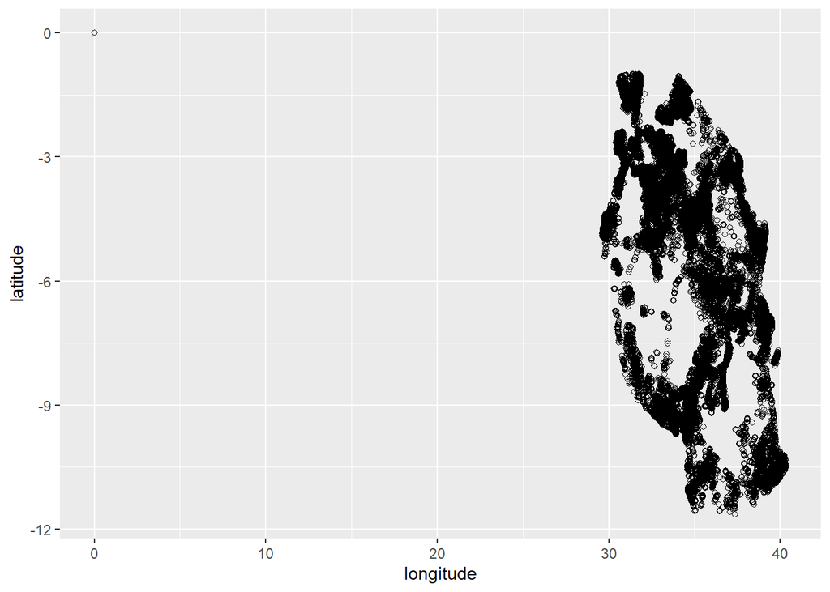

```r
# Let's display how latitude and longitude distribute

ggplot(Training_and_test_set, aes(x = longitude, y = latitude)) + geom_point(shape = 1)
```

```r
# We can clearly see that the vast majority of observations are concentrated in the right part of the graph. This implies that values equal to 0 are likely to be data quality issues

# Having more time to allocate on this, I would download/scrape a list of range (max and min latitude and longitude for Tanzania) in order to accurately understand which values are not right.
```

For the sake of this exercise, let’s remove and replace 0 values on `latitude` and `longitude` that certainly do not identify locations within Tanzania:

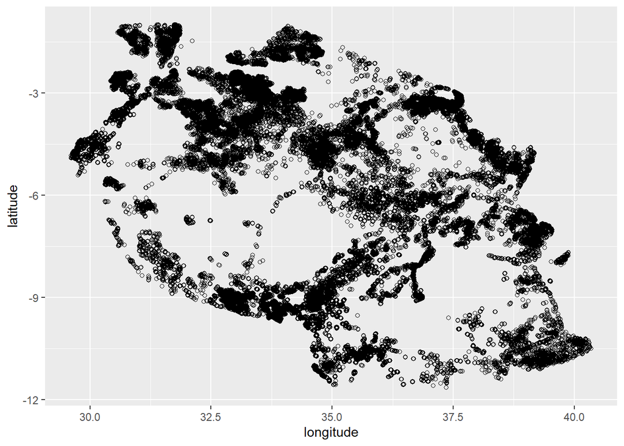

```r
# Replacing zero values with NA
Training_and_test_set <- Training_and_test_set %>%
  mutate(latitude = ifelse(latitude > -1e-06, NA, latitude)) %>%
  mutate(longitude = ifelse(longitude < 1e-06, NA, longitude))

# Displaying new distribution
ggplot(Training_and_test_set, aes(x = longitude, y = latitude)) + geom_point(shape = 1)
```

```r
# It seems like now we do have a far better distribution. Nevertheless we need to impute values for missing data.
```

In order to get values for replacing NA, let’s use the always populated fields `region`, and `district_code`to calculate mean latitude and longitude for each combination:

```r
# Let's compute averages in districts (just in case the above is also NA)
Training_and_test_set <- Training_and_test_set %>%
  group_by(region,district_code) %>%
  mutate(district.long = mean(longitude, na.rm = TRUE)) %>%
  mutate(district.lat = mean(latitude, na.rm = TRUE)) %>%
  ungroup()
```

```
## group_by: 2 grouping variables (region, district_code)
```

```
## ungroup: no grouping variables
```

```r
# Let's compute averages in regions (just in case the above is also NA)
Training_and_test_set <- Training_and_test_set %>%
  group_by(region) %>%
  mutate(region.long = mean(longitude, na.rm = TRUE)) %>%
  mutate(region.lat = mean(latitude, na.rm = TRUE)) %>%
  ungroup()
```

```
## group_by: one grouping variable (region)
## ungroup: no grouping variables
```

```r
# Impute missing longitude and latitude values
Training_and_test_set <- Training_and_test_set %>%
  mutate(longitude = ifelse(!is.na(longitude), longitude,
                            ifelse(!is.na(district.long), district.long, region.long))) %>%
  mutate(latitude = ifelse(!is.na(latitude), latitude,
                           ifelse(!is.na(district.lat), district.lat, region.lat)))

# Verify latitude and longitude no more have missing data
sum(is.na(Training_and_test_set$latitude)) + sum(is.na(Training_and_test_set$longitude))
```

```
## [1] 0
```

```r
# Changes have been properly implemented.
```

After this step, we can drop some geo features in order to avoid redundant information. My choice is to keep an high-level categorical feature, such as `region`, and the most precise geo features `latitude` and `longitude`.

We can then drop all other geo features, including those we created in previous step for data imputation.

```r
Training_and_test_set <- Training_and_test_set %>%
  select( - region_code,
          - district_code,
          - region.long,
          - region.lat,
          - district.long,
          - district.lat,
          - ward ,
          - subvillage)
```

Let’s explore last feature: `lga`

```r
Training_and_test_set %>%
  group_by(region, lga) %>%
  tally() %>%
  kbl() %>%
  kable_paper()
```

```
## group_by: 2 grouping variables (region, lga)
```

```
## tally: now 125 rows and 3 columns, one group variable remaining (region)
```

| region | lga | n |
| --- | --- | --- |
| Arusha | Arusha Rural | 1521 |
| Arusha | Arusha Urban | 82 |
| Arusha | Karatu | 402 |
| Arusha | Longido | 391 |
| Arusha | Meru | 1244 |
| Arusha | Monduli | 226 |
| Arusha | Ngorongoro | 245 |
| Dar es Salaam | Ilala | 633 |
| Dar es Salaam | Kinondoni | 121 |
| Dar es Salaam | Temeke | 266 |
| Dodoma | Bahi | 279 |
| Dodoma | Chamwino | 439 |
| Dodoma | Dodoma Urban | 467 |
| Dodoma | Kondoa | 644 |
| Dodoma | Kongwa | 460 |
| Dodoma | Mpwapwa | 490 |
| Iringa | Iringa Rural | 914 |
| Iringa | Kilolo | 434 |
| Iringa | Ludewa | 687 |
| Iringa | Makete | 789 |
| Iringa | Mufindi | 647 |
| Iringa | Njombe | 3128 |
| Kagera | Biharamulo | 501 |
| Kagera | Bukoba Rural | 622 |
| Kagera | Bukoba Urban | 112 |
| Kagera | Chato | 288 |
| Kagera | Karagwe | 967 |
| Kagera | Misenyi | 325 |
| Kagera | Muleba | 504 |
| Kagera | Ngara | 854 |

[output cut: 95 more lines]

```r
# This feature is quite interesting because it splits some region in urban and rural areas. We can extract from this variable this kind of information, creating a third category called "other" for all cases where `lga` is not urban nor rural


Training_and_test_set <- Training_and_test_set %>% mutate(lga = ifelse( grepl(" Rural", lga), "Rural",
                                     ifelse( grepl(" Urban", lga), "Urban","Other")))

# Convert again to factor
Training_and_test_set$lga <- as.factor(Training_and_test_set$lga)

# Let's check if transformation has been done right
summary(Training_and_test_set$lga)
```

```
## Other Rural Urban
## 60282 11814  2118
```

```r
# Transformation has been properly applied then
```

focus: `construction_year` and `date_recorded`

Since we have construction year and year when data were recorded, we can use these features to compute years of operation for each pump:

```r
# Computing operation years
Training_and_test_set <- Training_and_test_set %>%
  mutate(date_recorded = ymd(date_recorded)) %>%
  mutate(operation_years = lubridate::year(date_recorded) - construction_year) %>%
  mutate(operation_years = ifelse(operation_years < 0, NA, operation_years))

# I also put equal to NA all those cases where we get a negative number

# Let's check results:
summary(Training_and_test_set$operation_years)
```

```
##    Min. 1st Qu.  Median    Mean 3rd Qu.    Max.    NA's
##     0.0     8.0    26.0   712.9  2011.0  2013.0      12
```

```r
# Since we do have only 12 missing values for this new feature, we can impute the mean value for those cases

Training_and_test_set <- Training_and_test_set %>%
  mutate(operation_years = ifelse(is.na(operation_years), mean(operation_years, na.rm = T), operation_years))
```

Doing some research about whether in Tanzania, I found that the country has two rainy seasons: -> The short rains from late-October to late-December -> The long rains from March to May

So let’s create a feature reporting the season. Moreover, if a seasonal effect exists, it might be good to include the recorded day of the year as an integer from 1 to 365:

```r
# Calculating season
Training_and_test_set <- Training_and_test_set %>%
  mutate(day_of_year = yday(date_recorded)) %>%
  mutate(month_recorded = lubridate::month(date_recorded)) %>%
  mutate(season = ifelse( month_recorded <= 2, "dry short",
                          ifelse( month_recorded <= 5, "wet long",
                                  ifelse(month_recorded <= 9, "dry long", "wet short"))))

# Convert variable to factor
Training_and_test_set$season <- as.factor(Training_and_test_set$season)

# Let's remove redundant features
Training_and_test_set <- Training_and_test_set %>%
  select( - date_recorded, - month_recorded, - construction_year)
```

Now some features do have too many levels. According to my experience, having such a number of levels could impact model accuracy as well as computational time. I need to find a way to deal with these features.

Let’s explore `funder`:

```r
Training_and_test_set %>%
  group_by(funder) %>%
  tally()
```

```
## group_by: one grouping variable (funder)
```

```
## tally: now 2,141 rows and 2 columns, ungrouped
```

| funder | n |
| --- | --- |
|  | 4504 |
| 0 | 980 |
| A/co Germany | 19 |
| Aar | 41 |
| Abas Ka | 1 |
| Abasia | 51 |
| Abc-ihushi Development Cent | 1 |
| Abd | 8 |
| Abdala | 1 |
| Abddwe | 1 |

[output cut: 2131 more lines]

```r
# This feature has about 2k level. We need to keep only most frequent ones and collapse other levels into category "other"
```

In a real assignment, I would have investigated with Client the possibility to reduce levels creating significant buckets (for example, public vs private funders). Since I do not have enough information here to perform this task, I will simply collapse- levels of `funder` to 50 levels:

```r
# First of all, we do have blanks and 0 values (that, for the kind of information this field manages, have no means). Let's convert these two categories into category "Unknown"

Training_and_test_set$funder <- as.character(Training_and_test_set$funder)

Training_and_test_set$funder <- ifelse(Training_and_test_set$funder=="" | Training_and_test_set$funder=="0", "Unknown", Training_and_test_set$funder)


# Let's create 50 levels for this feature:
Training_and_test_set <- Training_and_test_set %>%
  mutate(funder= fct_lump(funder, n=49, other_level = "Other"))

# Convert feature to factor
Training_and_test_set$funder <- as.factor(Training_and_test_set$funder)

# Let's check results
levels(Training_and_test_set$funder)
```

```
##  [1] "Adb"                            "Adra"
##  [3] "Amref"                          "Ces(gmbh)"
##  [5] "Danida"                         "Ded"
##  [7] "Dh"                             "Dhv"
##  [9] "District Council"               "Dmdd"
## [11] "Dwe"                            "Dwsp"
## [13] "Fini Water"                     "Finw"
## [15] "Germany Republi"                "Government Of Tanzania"
## [17] "Hesawa"                         "Hifab"
## [19] "Isf"                            "Jaica"
## [21] "Jica"                           "Kiliwater"
## [23] "Kkkt"                           "Lawatefuka Water Supply"
## [25] "Lga"                            "Ministry Of Water"
## [27] "Mission"                        "Netherlands"
## [29] "Norad"                          "Oxfam"
## [31] "Plan Int"                       "Private"
## [33] "Private Individual"             "Rc"
## [35] "Rc Church"                      "Roman"
## [37] "Rudep"                          "Rural Water Supply And Sanitat"
## [39] "Rwssp"                          "Shipo"
## [41] "Tasaf"                          "Tcrs"
## [43] "Unicef"                         "Unknown"
## [45] "Water"                          "Wateraid"
## [47] "World Bank"                     "World Vision"
## [49] "Wsdp"                           "Other"
```

Let’s explore `installer`:

```r
Training_and_test_set %>%
  group_by(installer) %>%
  tally()
```

```
## group_by: one grouping variable (installer)
```

```
## tally: now 2,411 rows and 2 columns, ungrouped
```

| installer | n |
| --- | --- |
|  | 4532 |
| - | 3 |
| 0 | 980 |
| A.D.B | 1 |
| AAR | 5 |
| ABASIA | 34 |
| ABD | 1 |
| ABDALA | 1 |
| ABDUL | 2 |
| AC | 5 |

[output cut: 2401 more lines]

```r
# Also this feature has more than 2k level. We need to keep only most frequent ones and collapse other levels into category "other"
```

In a real assignment, I would have investigated with Client the possibility to reduce levels creating significant buckets (for example, public vs private installers). Since I do not have enough information here to perform this task, I will simply collapse levels of `installer` to 50 levels:

```r
# First of all we do have blanks, "-" and 0 values (that, for the kind of information this field manages, have no means). Let's convert these three categories into category "Unknown"

Training_and_test_set$installer <- as.character(Training_and_test_set$installer)

Training_and_test_set$installer <- ifelse(Training_and_test_set$installer=="" | Training_and_test_set$installer=="0" | Training_and_test_set$installer=="-", "Unknown", Training_and_test_set$installer)


# Let's create 50 levels for this feature:
Training_and_test_set <- Training_and_test_set %>%
  mutate(installer= fct_lump(installer, n=49, other_level = "Other"))

# Convert feature to factor
Training_and_test_set$installer <- as.factor(Training_and_test_set$installer)

# Let's check results
levels(Training_and_test_set$installer)
```

```
##  [1] "ACRA"                       "AMREF"
##  [3] "Central government"         "CES"
##  [5] "Commu"                      "Community"
##  [7] "Da"                         "DANID"
##  [9] "DANIDA"                     "DH"
## [11] "Distri"                     "District council"
## [13] "District Council"           "Dmdd"
## [15] "DW"                         "DWE"
## [17] "DWSP"                       "FinW"
## [19] "FW"                         "Gove"
## [21] "Gover"                      "Government"
## [23] "Handeni Trunk Main("        "Hesawa"
## [25] "HESAWA"                     "Idara ya maji"
## [27] "Kiliwater"                  "KKKT"
## [29] "KKKT _ Konde and DWE"       "Lawatefuka water sup"
## [31] "LGA"                        "Magadini-Makiwaru wa"
## [33] "NORAD"                      "OXFAM"
## [35] "RC"                         "RWE"
## [37] "SEMA"                       "Sengerema Water Department"
## [39] "TASAF"                      "TCRS"
## [41] "TWESA"                      "UNICEF"
## [43] "Unknown"                    "Villagers"
## [45] "WEDECO"                     "World vision"
## [47] "World Vision"               "WU"
## [49] "WVT"                        "Other"
```

Let’s explore `wpt_name`:

```r
Training_and_test_set %>%
  group_by(wpt_name) %>%
  tally()
```

```
## group_by: one grouping variable (wpt_name)
```

```
## tally: now 45,684 rows and 2 columns, ungrouped
```

| wpt_name | n |
| --- | --- |
| 24 | 2 |
| A Kulwa | 1 |
| A Saidi | 1 |
| Abass | 1 |
| Abbas | 1 |
| Abdala Hamisi | 1 |
| Abdala Mwandute | 1 |
| Abdalaa | 1 |
| Abdalah | 5 |
| Abdalah Ali | 1 |

[output cut: 9990 more lines]

```r
# This feature presents about 45k unique levels. At first look, this is a bit strange because I would have expected a unique name for each pump. In a real assignment, I would have asked Client about this, but, for the sake of this exercise, let's drop this variable that it is too fragmented

Training_and_test_set <- Training_and_test_set %>%
  select(-wpt_name)
```

focus: `scheme_management`

```r
Training_and_test_set %>%
  group_by(scheme_management) %>%
  tally() %>%
  kbl() %>%
  kable_paper()
```

```
## group_by: one grouping variable (scheme_management)
```

```
## tally: now 13 rows and 2 columns, ungrouped
```

| scheme_management | n |
| --- | --- |
|  | 4846 |
| Company | 1341 |
| None | 1 |
| Other | 996 |
| Parastatal | 2122 |
| Private operator | 1326 |
| SWC | 123 |
| Trust | 92 |
| VWC | 45903 |
| WUA | 3551 |
| WUG | 6476 |
| Water Board | 3462 |
| Water authority | 3975 |

```r
# Let's replace blanks and "None" with "Unknown"

# Convert feature to character
Training_and_test_set$scheme_management <- as.character(Training_and_test_set$scheme_management)

# Add unknown category
Training_and_test_set$scheme_management <- ifelse(Training_and_test_set$scheme_management=="" | Training_and_test_set$scheme_management=="None", "Unknown", Training_and_test_set$scheme_management)

# Convert data type to factor
Training_and_test_set$scheme_management <- as.factor(Training_and_test_set$scheme_management)
```

focus: `scheme_name`

```r
Training_and_test_set %>%
  group_by(scheme_name) %>%
  tally()
```

```
## group_by: one grouping variable (scheme_name)
```

```
## tally: now 2,869 rows and 2 columns, ungrouped
```

| scheme_name | n |
| --- | --- |
|  | 35231 |
| 14 Kambarage | 6 |
| A | 50 |
| ADP | 10 |
| ADP Simbo | 27 |
| ADP Simbu | 2 |
| ADRA | 10 |
| AIC | 2 |
| AIC kahunda | 1 |
| AMREF | 4 |

[output cut: 2859 more lines]

```r
# This feature seems to be a detailed version of scheme_management but it is very dirty (several names seem to be the same but recorded with different label). I do prefer to drop this one because, for the sake of this exercise, properly clean data would require too much time

Training_and_test_set <- Training_and_test_set %>%
  select(-scheme_name)
```

focus: `extraction_type_class` vs `extraction_type_group`vs `extraction_type`

```r
Training_and_test_set %>%
  group_by(extraction_type_class, extraction_type_group, extraction_type) %>%
  tally() %>%
  kbl() %>%
  kable_paper()
```

```
## group_by: 3 grouping variables (extraction_type_class, extraction_type_group, extraction_type)
```

```
## tally: now 18 rows and 4 columns, 2 group variables remaining (extraction_type_class, extraction_type_group)
```

| extraction_type_class | extraction_type_group | extraction_type | n |
| --- | --- | --- | --- |
| gravity | gravity | gravity | 33259 |
| handpump | afridev | afridev | 2207 |
| handpump | india mark ii | india mark ii | 3027 |
| handpump | india mark iii | india mark iii | 134 |
| handpump | nira/tanira | nira/tanira | 10194 |
| handpump | other handpump | other - mkulima/shinyanga | 2 |
| handpump | other handpump | other - play pump | 101 |
| handpump | other handpump | other - swn 81 | 284 |
| handpump | other handpump | walimi | 60 |
| handpump | swn 80 | swn 80 | 4581 |
| motorpump | mono | mono | 3628 |
| motorpump | other motorpump | cemo | 108 |
| motorpump | other motorpump | climax | 41 |
| other | other | other | 8099 |
| rope pump | rope pump | other - rope pump | 572 |
| submersible | submersible | ksb | 1788 |
| submersible | submersible | submersible | 5977 |
| wind-powered | wind-powered | windmill | 152 |

```r
# It seems like each variable is a more detailed version of the previous one. Nevertheless, `extraction_type_group`vs `extraction_type` are very similar so we will drop the mid-level

Training_and_test_set <- Training_and_test_set %>%
  select(-extraction_type_group)

# After first run of the model I noticed that `extraction_type`="other - mkulima/shinyanga" only exists as a level for training set (while it is not present in test set)

Training_and_test_set %>%
  select(Split, extraction_type) %>%
  distinct() %>%
  arrange(extraction_type) %>%
  kbl() %>%
  kable_paper()
```

```
## distinct: removed 74,179 rows (>99%), 35 rows remaining
```

| Split | extraction_type |
| --- | --- |
| Training set | afridev |
| Test set | afridev |
| Training set | cemo |
| Test set | cemo |
| Training set | climax |
| Test set | climax |
| Training set | gravity |
| Test set | gravity |
| Training set | india mark ii |
| Test set | india mark ii |
| Training set | india mark iii |
| Test set | india mark iii |
| Training set | ksb |
| Test set | ksb |
| Training set | mono |
| Test set | mono |
| Training set | nira/tanira |
| Test set | nira/tanira |
| Training set | other |
| Test set | other |
| Training set | other - mkulima/shinyanga |
| Training set | other - play pump |
| Test set | other - play pump |
| Training set | other - rope pump |
| Test set | other - rope pump |
| Training set | other - swn 81 |
| Test set | other - swn 81 |
| Training set | submersible |
| Test set | submersible |
| Training set | swn 80 |
| Test set | swn 80 |
| Training set | walimi |
| Test set | walimi |
| Training set | windmill |
| Test set | windmill |

```r
levels(Training_and_test_set$extraction_type)
```

```
##  [1] "afridev"                   "cemo"
##  [3] "climax"                    "gravity"
##  [5] "india mark ii"             "india mark iii"
##  [7] "ksb"                       "mono"
##  [9] "nira/tanira"               "other"
## [11] "other - mkulima/shinyanga" "other - play pump"
## [13] "other - rope pump"         "other - swn 81"
## [15] "submersible"               "swn 80"
## [17] "walimi"                    "windmill"
```

```r
# We will put this in "other" bucket

Training_and_test_set$extraction_type <- as.character(Training_and_test_set$extraction_type)

Training_and_test_set$extraction_type <- ifelse(Training_and_test_set$extraction_type=="other - mkulima/shinyanga", "other", Training_and_test_set$extraction_type)

Training_and_test_set$extraction_type <- as.factor(Training_and_test_set$extraction_type)

levels(Training_and_test_set$extraction_type)
```

```
##  [1] "afridev"           "cemo"              "climax"
##  [4] "gravity"           "india mark ii"     "india mark iii"
##  [7] "ksb"               "mono"              "nira/tanira"
## [10] "other"             "other - play pump" "other - rope pump"
## [13] "other - swn 81"    "submersible"       "swn 80"
## [16] "walimi"            "windmill"
```

focus: `num_private`

```r
Training_and_test_set %>%
  group_by(num_private) %>%
  tally() %>%
  kbl() %>%
  kable_paper() %>%
  kable_styling(bootstrap_options = c("striped", "hover", "condensed"), full_width = F)
```

```
## group_by: one grouping variable (num_private)
```

```
## tally: now 68 rows and 2 columns, ungrouped
```

| num_private | n |
| --- | --- |
| 0 | 73263 |
| 1 | 94 |
| 2 | 31 |
| 3 | 38 |
| 4 | 30 |
| 5 | 60 |
| 6 | 92 |
| 7 | 31 |
| 8 | 58 |
| 9 | 4 |
| 10 | 5 |
| 11 | 18 |
| 12 | 7 |
| 13 | 1 |
| 14 | 3 |
| 15 | 47 |
| 16 | 13 |
| 17 | 24 |
| 20 | 14 |
| 22 | 11 |
| 23 | 2 |
| 24 | 5 |
| 25 | 14 |
| 26 | 3 |
| 27 | 2 |
| 30 | 1 |
| 32 | 45 |
| 34 | 13 |
| 35 | 1 |
| 38 | 4 |
| 39 | 34 |
| 41 | 12 |
| 42 | 1 |
| 45 | 41 |
| 47 | 27 |
| 50 | 7 |
| 55 | 1 |
| 58 | 4 |
| 60 | 1 |
| 61 | 3 |
| 62 | 1 |
| 65 | 27 |
| 80 | 17 |
| 87 | 1 |
| 93 | 37 |
| 94 | 1 |
| 102 | 28 |
| 111 | 1 |
| 120 | 9 |
| 131 | 1 |
| 136 | 1 |
| 141 | 2 |
| 150 | 6 |
| 160 | 1 |
| 180 | 3 |
| 213 | 1 |
| 240 | 1 |
| 280 | 1 |
| 300 | 1 |
| 420 | 1 |
| 450 | 1 |
| 668 | 1 |
| 669 | 1 |
| 672 | 1 |
| 698 | 1 |
| 755 | 1 |
| 1402 | 1 |
| 1776 | 1 |

```r
# This variable is mostly 0, while all the other numbers have very few occurrences. We can then keep this variable, focusing on difference between 0 and other values

Training_and_test_set$num_private <- ifelse(Training_and_test_set$num_private == 0, "Zero", "Non zero")

# Convert to factor
Training_and_test_set$num_private <- as.factor(Training_and_test_set$num_private)

# Checking results
summary(Training_and_test_set$num_private)
```

```
## Non zero     Zero
##      951    73263
```

It should be noted that there are zero values also for features `population`, `gps_height` and `amount_tsh`. Since data dictionary for this case is not very clear, I do not have enough information to state these are data quality issues. In a real assignment I would have discussed this with Client but, for the sake of the exercise, I will consider these values to be ok.

focus: `public_meeting`

```r
Training_and_test_set %>%
  group_by(public_meeting) %>%
  tally() %>%
  kbl() %>%
  kable_paper()
```

```
## group_by: one grouping variable (public_meeting)
```

```
## tally: now 3 rows and 2 columns, ungrouped
```

| public_meeting | n |
| --- | --- |
| FALSE | 6345 |
| TRUE | 63734 |
| NA | 4135 |

```r
# We do have about 4k NAs that need to be imputed. I will replace NAs with "Unknown" category

Training_and_test_set$public_meeting <- as.character(Training_and_test_set$public_meeting)

Training_and_test_set$public_meeting <- ifelse(is.na(Training_and_test_set$public_meeting), "Unknown", Training_and_test_set$public_meeting)

Training_and_test_set$public_meeting <- as.factor(Training_and_test_set$public_meeting)
```

focus: `permit`

```r
Training_and_test_set %>%
  group_by(permit) %>%
  tally() %>%
  kbl() %>%
  kable_paper()
```

```
## group_by: one grouping variable (permit)
```

```
## tally: now 3 rows and 2 columns, ungrouped
```

| permit | n |
| --- | --- |
| FALSE | 21829 |
| TRUE | 48592 |
| NA | 3793 |

```r
# We do have about 4k NAs that need to be imputed. I will replace NAs with "Unknown" category

Training_and_test_set$permit <- as.character(Training_and_test_set$permit)

Training_and_test_set$permit <- ifelse(is.na(Training_and_test_set$permit), "Unknown", Training_and_test_set$permit)

Training_and_test_set$permit <- as.factor(Training_and_test_set$permit)
```

Now let’s check if we do still have have NAs and blank across dataset:

```r
sum(is.na(Training_and_test_set))
```

```
## [1] 0
```

```r
sum(Training_and_test_set=="")
```

```
## [1] 0
```

```r
# We had successfully removed all NAs and blank values. Dataset is ready for modeling
```

Now that dataset is clean, let’s check left variables:

```r
colnames(Training_and_test_set)
```

```
##  [1] "amount_tsh"            "funder"                "gps_height"
##  [4] "installer"             "longitude"             "latitude"
##  [7] "num_private"           "basin"                 "region"
## [10] "lga"                   "population"            "public_meeting"
## [13] "scheme_management"     "permit"                "extraction_type"
## [16] "extraction_type_class" "management"            "management_group"
## [19] "payment_type"          "water_quality"         "quantity"
## [22] "source"                "source_type"           "source_class"
## [25] "waterpoint_type"       "status_group"          "id"
## [28] "Split"                 "operation_years"       "day_of_year"
## [31] "season"
```

### DATA EXPLORATION

Let’s explore how independent variables interact with target variable:

```r
#autoEDA::autoEDA(Training_and_test_set, "status_group")
```

Let’s make a plot to understand which is actual situation in terms of working/faulty pumps across the Country:

```
## filter: removed 14,850 rows (20%), 59,364 rows remaining
```

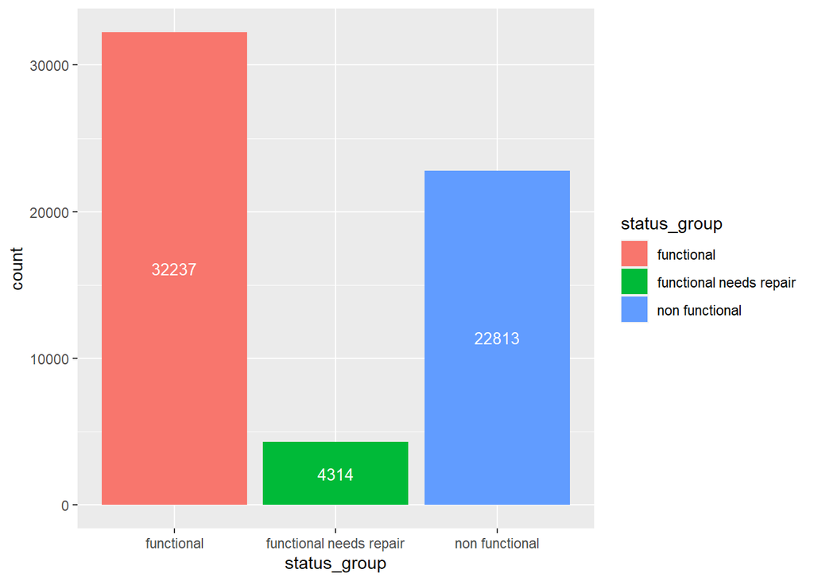

```r
Training_and_test_set %>%
  filter(status_group!="NOT AVAILABLE") %>%
  ggplot(mapping = aes(x=status_group, fill=status_group)) +
  geom_bar(stat = "count") +
  stat_count(geom = "text", colour = "white", size = 3.5,
aes(label = ..count..),position=position_stack(vjust=0.5))
```

It seems clear from the graph above why Tanzanian Ministry of Water is interested in addressing the problem. It seems that out of 59.364 water pumps located across Tanzania, almost 46% are not working properly (need repair or not working at all)

## NUMERICAL FEATURES STUDY

Let’s see how `latitude` and `longitude` behave with respect to target variable:

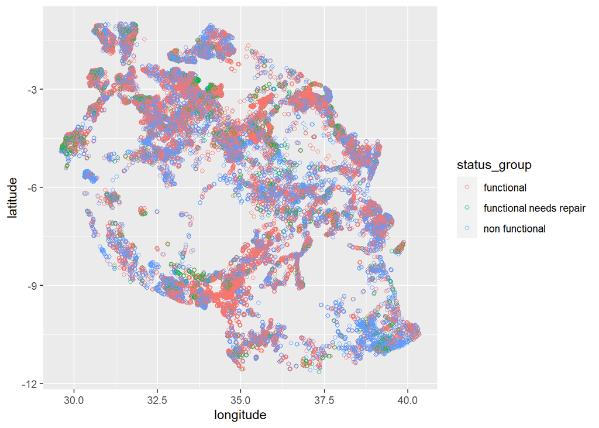

```r
Training_and_test_set %>%
  filter(status_group!="NOT AVAILABLE") %>%
ggplot(mapping =  aes(x = longitude, y = latitude)) +
  geom_point(shape = 1,aes(color=status_group))
```

Looking at this scatterplot we can already see that some categories are concentrated at specific latitudes and longitudes. For example, at the bottom right corner, there is a strong prevalence of non functional water pumps. That’s why I would bet this variable will be important for models in a later phase.

Another way to look at this is:

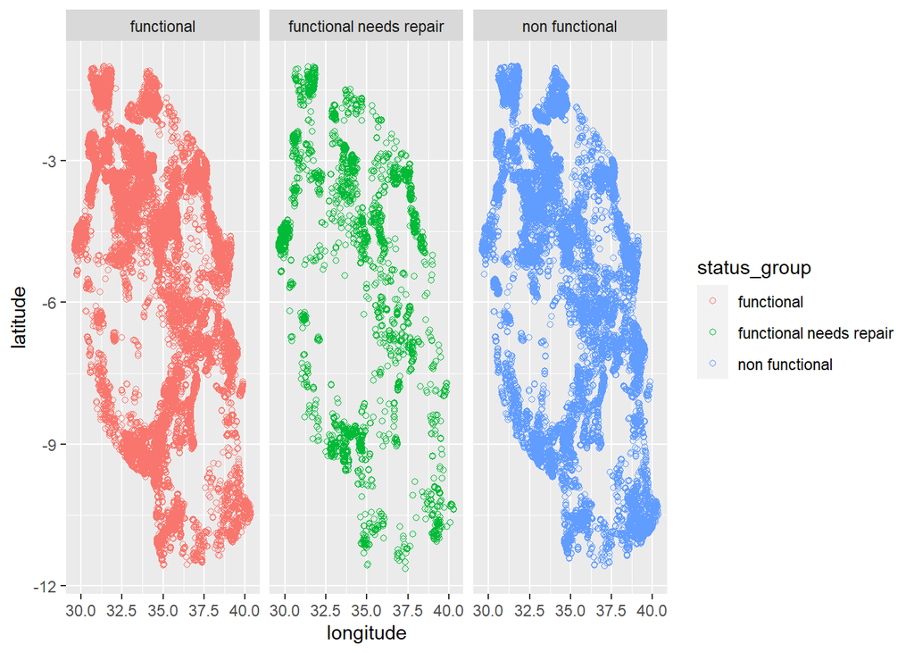

```r
Training_and_test_set %>%
  filter(status_group!="NOT AVAILABLE") %>%
ggplot(mapping =  aes(x = longitude, y = latitude)) +
  geom_point(shape = 1,aes(color=status_group)) +
   facet_grid(. ~ status_group)
```

We can also study this phenomenon using histograms :

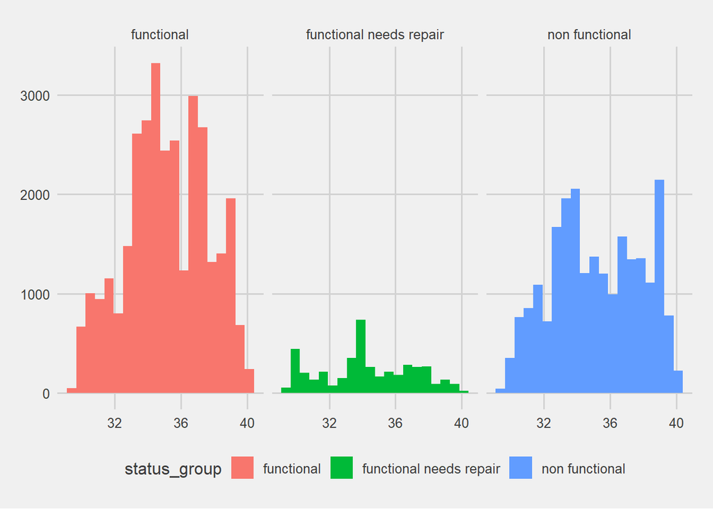

```r
# Explore longitude
Training_and_test_set %>%
  filter(Split=="Training set") %>%
ggplot(mapping=aes(x = longitude,fill=status_group)) +
  geom_histogram(bins = 20) +
  facet_grid( ~ status_group) +
  theme_fivethirtyeight()
```

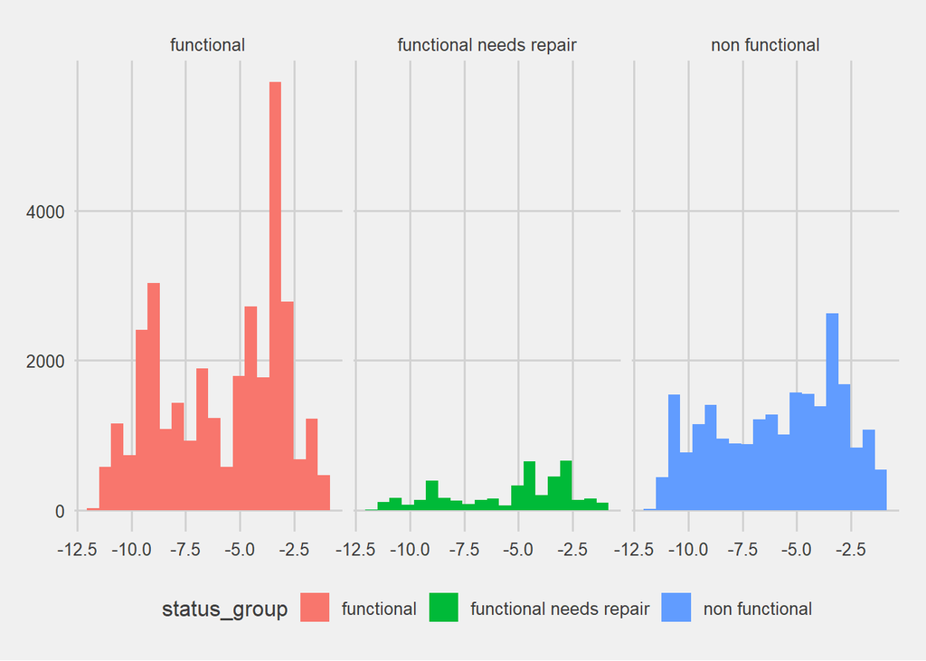

```r
# Explore latitude
Training_and_test_set %>%
  filter(Split=="Training set") %>%
ggplot(mapping=aes(x = latitude,fill=status_group)) +
  geom_histogram(bins = 20) +
  facet_grid( ~ status_group) +
  theme_fivethirtyeight()
```

Let’s see how `amount_tsh` behave with respect to target variable:

```r
Training_and_test_set %>%
    filter(status_group!="NOT AVAILABLE") %>%
    select(amount_tsh, status_group) %>%
    split(.$status_group) %>%
    map(summary)
```

```
## $functional
##    amount_tsh                        status_group
##  Min.   :     0.0   functional             :32237
##  1st Qu.:     0.0   functional needs repair:    0
##  Median :     0.0   non functional         :    0
##  Mean   :   462.1   NOT AVAILABLE          :    0
##  3rd Qu.:    50.0
##  Max.   :350000.0
##
## $`functional needs repair`
##    amount_tsh                        status_group
##  Min.   :     0.0   functional             :   0
##  1st Qu.:     0.0   functional needs repair:4314
##  Median :     0.0   non functional         :   0
##  Mean   :   267.3   NOT AVAILABLE          :   0
##  3rd Qu.:    50.0
##  Max.   :100000.0
##
## $`non functional`
##    amount_tsh                        status_group
##  Min.   :     0.0   functional             :    0
##  1st Qu.:     0.0   functional needs repair:    0
##  Median :     0.0   non functional         :22813
##  Mean   :   123.5   NOT AVAILABLE          :    0
##  3rd Qu.:     0.0
##  Max.   :117000.0
##
## $`NOT AVAILABLE`
##    amount_tsh                   status_group
##  Min.   : NA   functional             :0
##  1st Qu.: NA   functional needs repair:0
##  Median : NA   non functional         :0
##  Mean   :NaN   NOT AVAILABLE          :0
##  3rd Qu.: NA
##  Max.   : NA
```

What is really interesting about this feature is that it seems very correlated to target. The less the `amount_tsh` the more is likely that pump is faulty. We can indeed see that mean value decrease from “functional” (where it is 462) to “non functional” (where it is 123). My consideration here is that bigger waterpoints are less subject to failures than smaller ones.

Let’s explore `gps_height`:

```r
Training_and_test_set %>%
    filter(status_group!="NOT AVAILABLE") %>%
    select(gps_height, status_group) %>%
    split(.$status_group) %>%
    map(summary)
```

```
## $functional
##    gps_height                      status_group
##  Min.   : -90.0   functional             :32237
##  1st Qu.:   0.0   functional needs repair:    0
##  Median : 553.0   non functional         :    0
##  Mean   : 740.6   NOT AVAILABLE          :    0
##  3rd Qu.:1405.0
##  Max.   :2628.0
##
## $`functional needs repair`
##    gps_height                      status_group
##  Min.   : -51.0   functional             :   0
##  1st Qu.:   0.0   functional needs repair:4314
##  Median : 385.5   non functional         :   0
##  Mean   : 628.0   NOT AVAILABLE          :   0
##  3rd Qu.:1243.8
##  Max.   :2770.0
##
## $`non functional`
##    gps_height                      status_group
##  Min.   : -59.0   functional             :    0
##  1st Qu.:   0.0   functional needs repair:    0
##  Median : 293.0   non functional         :22813
##  Mean   : 574.7   NOT AVAILABLE          :    0
##  3rd Qu.:1211.0
##  Max.   :2627.0
##
## $`NOT AVAILABLE`
##    gps_height                   status_group
##  Min.   : NA   functional             :0
##  1st Qu.: NA   functional needs repair:0
##  Median : NA   non functional         :0
##  Mean   :NaN   NOT AVAILABLE          :0
##  3rd Qu.: NA
##  Max.   : NA
```

Even this variable seems to have some predict power because the The less the `gps_height` more is likely that pump is faulty.

Let’s look at `population`:

```r
Training_and_test_set %>%
    filter(status_group!="NOT AVAILABLE") %>%
    select(population, status_group) %>%
    split(.$status_group) %>%
    map(summary)
```

```
## $functional
##    population                       status_group
##  Min.   :    0.0   functional             :32237
##  1st Qu.:    0.0   functional needs repair:    0
##  Median :   40.0   non functional         :    0
##  Mean   :  187.7   NOT AVAILABLE          :    0
##  3rd Qu.:  200.0
##  Max.   :30500.0
##
## $`functional needs repair`
##    population                       status_group
##  Min.   :    0.0   functional             :   0
##  1st Qu.:    0.0   functional needs repair:4314
##  Median :   25.0   non functional         :   0
##  Mean   :  175.2   NOT AVAILABLE          :   0
##  3rd Qu.:  245.8
##  Max.   :15300.0
##
## $`non functional`
##    population                      status_group
##  Min.   :   0.0   functional             :    0
##  1st Qu.:   0.0   functional needs repair:    0
##  Median :   1.0   non functional         :22813
##  Mean   : 170.1   NOT AVAILABLE          :    0
##  3rd Qu.: 230.0
##  Max.   :9865.0
##
## $`NOT AVAILABLE`
##    population                   status_group
##  Min.   : NA   functional             :0
##  1st Qu.: NA   functional needs repair:0
##  Median : NA   non functional         :0
##  Mean   :NaN   NOT AVAILABLE          :0
##  3rd Qu.: NA
##  Max.   : NA
```

Even this variable seems to have some predict power because the The less the `pupulation` the more is likely that pump is faulty.

And lastly let’s look at `operation_years`, one of the features we decided to create starting from existing data:

```r
Training_and_test_set %>%
    filter(status_group!="NOT AVAILABLE") %>%
    select(operation_years, status_group) %>%
    split(.$status_group) %>%
    map(summary)
```

```
## $functional
##  operation_years                   status_group
##  Min.   :   0.0   functional             :32237
##  1st Qu.:   5.0   functional needs repair:    0
##  Median :  17.0   non functional         :    0
##  Mean   : 665.5   NOT AVAILABLE          :    0
##  3rd Qu.:2011.0
##  Max.   :2013.0
##
## $`functional needs repair`
##  operation_years                   status_group
##  Min.   :   0.0   functional             :   0
##  1st Qu.:  12.0   functional needs repair:4314
##  Median :  33.0   non functional         :   0
##  Mean   : 842.9   NOT AVAILABLE          :   0
##  3rd Qu.:2011.0
##  Max.   :2013.0
##
## $`non functional`
##  operation_years                   status_group
##  Min.   :   0.0   functional             :    0
##  1st Qu.:  14.0   functional needs repair:    0
##  Median :  33.0   non functional         :22813
##  Mean   : 749.3   NOT AVAILABLE          :    0
##  3rd Qu.:2011.0
##  Max.   :2013.0
##
## $`NOT AVAILABLE`
##  operation_years                  status_group
##  Min.   : NA     functional             :0
##  1st Qu.: NA     functional needs repair:0
##  Median : NA     non functional         :0
##  Mean   :NaN     NOT AVAILABLE          :0
##  3rd Qu.: NA
##  Max.   : NA
```

As one would expect, here seems that older pumps are more likely to be faulty.

## CATEGORICAL FEATURES STUDY

Let’s look at `payment_type`:

```r
Training_and_test_set %>%
  filter(Split!="Test set") %>%
  select(payment_type,
         status_group) %>%
  tbl_summary(by=status_group, percent = "row") %>%
  add_n()
```

| **Characteristic** | **N** | **functional**, N = 32,237<sup>1</sup> | **functional needs repair**, N = 4,314<sup>1</sup> | **non functional**, N = 22,813<sup>1</sup> | **NOT AVAILABLE**, N = 0<sup>1</sup> |
| --- | --- | --- | --- | --- | --- |
| payment_type | 59,364 |  |  |  |  |
| annually |  | 2,740 (75%) | 247 (6.8%) | 655 (18%) | 0 (0%) |
| monthly |  | 5,482 (66%) | 927 (11%) | 1,891 (23%) | 0 (0%) |
| never pay |  | 11,371 (45%) | 1,906 (7.5%) | 12,060 (48%) | 0 (0%) |
| on failure |  | 2,429 (62%) | 277 (7.1%) | 1,208 (31%) | 0 (0%) |
| other |  | 610 (58%) | 118 (11%) | 325 (31%) | 0 (0%) |
| per bucket |  | 6,089 (68%) | 409 (4.6%) | 2,486 (28%) | 0 (0%) |
| unknown |  | 3,516 (43%) | 430 (5.3%) | 4,188 (51%) | 0 (0%) |

<sup>*1*</sup> n (%)

A powerful way to look at this is:

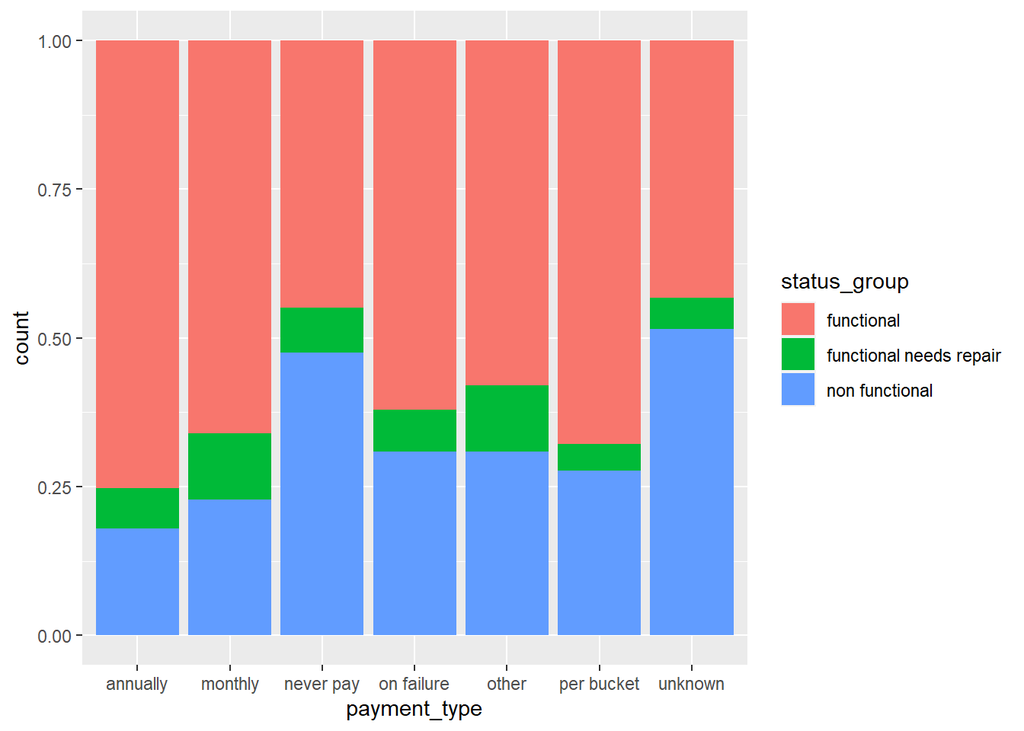

```r
Training_and_test_set %>%
  filter(Split!="Test set") %>%
  ggplot(mapping = aes(x=payment_type,fill=status_group)) +
  geom_bar(stat="count", position = "fill")
```

Let’s explore `source`:

```r
Training_and_test_set %>%
  filter(Split!="Test set") %>%
  select(source,
         status_group) %>%
  tbl_summary(by=status_group, percent = "row") %>%
  add_n()
```

| **Characteristic** | **N** | **functional**, N = 32,237<sup>1</sup> | **functional needs repair**, N = 4,314<sup>1</sup> | **non functional**, N = 22,813<sup>1</sup> | **NOT AVAILABLE**, N = 0<sup>1</sup> |
| --- | --- | --- | --- | --- | --- |
| source | 59,364 |  |  |  |  |
| dam |  | 253 (39%) | 24 (3.7%) | 378 (58%) | 0 (0%) |
| hand dtw |  | 497 (57%) | 17 (1.9%) | 360 (41%) | 0 (0%) |
| lake |  | 162 (21%) | 12 (1.6%) | 589 (77%) | 0 (0%) |
| machine dbh |  | 5,417 (49%) | 491 (4.4%) | 5,161 (47%) | 0 (0%) |
| other |  | 126 (60%) | 1 (0.5%) | 84 (40%) | 0 (0%) |
| rainwater harvesting |  | 1,385 (60%) | 313 (14%) | 595 (26%) | 0 (0%) |
| river |  | 5,465 (57%) | 1,221 (13%) | 2,926 (30%) | 0 (0%) |
| shallow well |  | 8,309 (49%) | 955 (5.7%) | 7,537 (45%) | 0 (0%) |
| spring |  | 10,591 (62%) | 1,276 (7.5%) | 5,153 (30%) | 0 (0%) |
| unknown |  | 32 (48%) | 4 (6.1%) | 30 (45%) | 0 (0%) |

<sup>*1*</sup> n (%)

We can note here that when `source` is a lake, the probability that pumps is not working properly is very high. This variable can also be related to geographical location seen before.

Let’s display this:

```
## filter: removed 14,850 rows (20%), 59,364 rows remaining
```

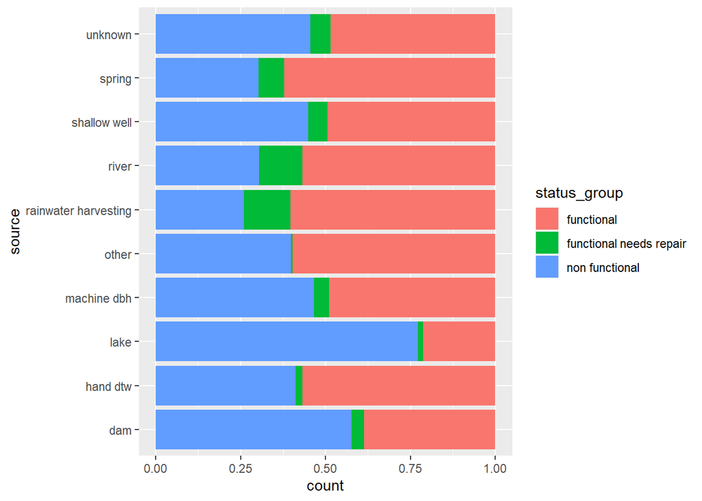

```r
Training_and_test_set %>%
  filter(Split!="Test set") %>%
  ggplot(mapping = aes(x=source,fill=status_group)) +
  geom_bar(stat="count", position = "fill") +
  coord_flip()
```

Let’s study `quantity`:

```r
Training_and_test_set %>%
  filter(Split!="Test set") %>%
  select(quantity,
         status_group) %>%
  tbl_summary(by=status_group, percent = "row") %>%
  add_n()
```

| **Characteristic** | **N** | **functional**, N = 32,237<sup>1</sup> | **functional needs repair**, N = 4,314<sup>1</sup> | **non functional**, N = 22,813<sup>1</sup> | **NOT AVAILABLE**, N = 0<sup>1</sup> |
| --- | --- | --- | --- | --- | --- |
| quantity | 59,364 |  |  |  |  |
| dry |  | 157 (2.5%) | 37 (0.6%) | 6,049 (97%) | 0 (0%) |
| enough |  | 21,635 (65%) | 2,398 (7.2%) | 9,132 (28%) | 0 (0%) |
| insufficient |  | 7,908 (52%) | 1,450 (9.6%) | 5,761 (38%) | 0 (0%) |
| seasonal |  | 2,324 (57%) | 415 (10%) | 1,309 (32%) | 0 (0%) |
| unknown |  | 213 (27%) | 14 (1.8%) | 562 (71%) | 0 (0%) |

<sup>*1*</sup> n (%)

Even looking at these feature there are some interesting elements. For example, if we consider feature `quantity` we can clearly see that category “dry” is strongly indicative of a non functional pump. This implies that this variable will be very useful in predicting water pumps status.

From a graphical point of view:

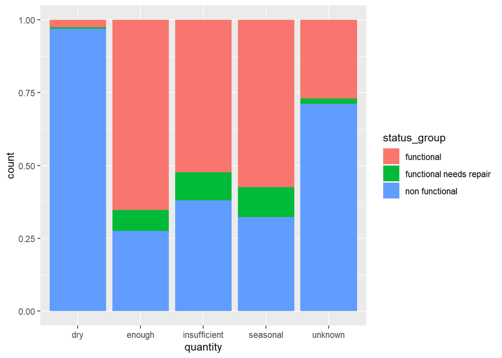

```r
Training_and_test_set %>%
  filter(Split!="Test set") %>%
  ggplot(mapping = aes(x=quantity,fill=status_group)) +
  geom_bar(stat="count", position = "fill")
```

Let’s explore `basin`:

```r
Training_and_test_set %>%
  filter(Split!="Test set") %>%
  select(basin,
         status_group) %>%
  tbl_summary(by=status_group, percent = "row") %>%
  add_n()
```

| **Characteristic** | **N** | **functional**, N = 32,237<sup>1</sup> | **functional needs repair**, N = 4,314<sup>1</sup> | **non functional**, N = 22,813<sup>1</sup> | **NOT AVAILABLE**, N = 0<sup>1</sup> |
| --- | --- | --- | --- | --- | --- |
| basin | 59,364 |  |  |  |  |
| Internal |  | 4,482 (58%) | 557 (7.2%) | 2,746 (35%) | 0 (0%) |
| Lake Nyasa |  | 3,324 (65%) | 250 (4.9%) | 1,511 (30%) | 0 (0%) |
| Lake Rukwa |  | 1,000 (41%) | 270 (11%) | 1,184 (48%) | 0 (0%) |
| Lake Tanganyika |  | 3,107 (48%) | 742 (12%) | 2,583 (40%) | 0 (0%) |
| Lake Victoria |  | 5,078 (50%) | 986 (9.7%) | 4,148 (41%) | 0 (0%) |
| Pangani |  | 5,372 (60%) | 477 (5.3%) | 3,091 (35%) | 0 (0%) |
| Rufiji |  | 5,068 (64%) | 437 (5.5%) | 2,471 (31%) | 0 (0%) |
| Ruvuma / Southern Coast |  | 1,670 (37%) | 326 (7.3%) | 2,497 (56%) | 0 (0%) |
| Wami / Ruvu |  | 3,136 (52%) | 269 (4.5%) | 2,582 (43%) | 0 (0%) |

<sup>*1*</sup> n (%)

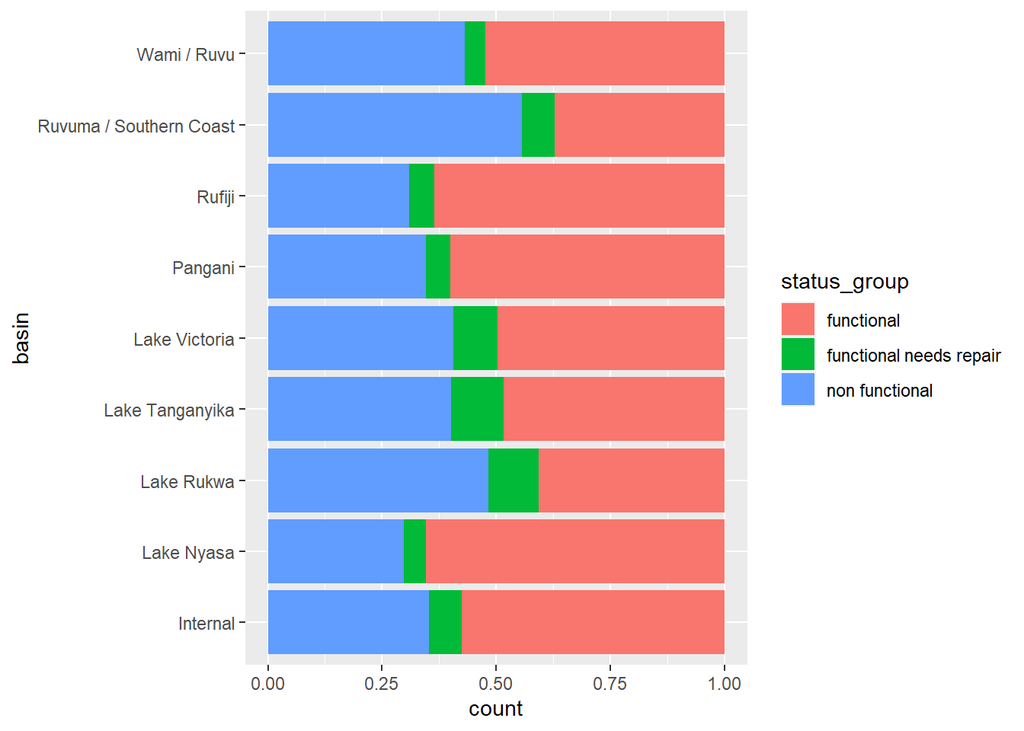

```r
Training_and_test_set %>%
  filter(Split!="Test set") %>%
  ggplot(mapping = aes(x=basin,fill=status_group)) +
  geom_bar(stat="count", position = "fill") +
  coord_flip()
```

Again, geo features are very interesting. Here, for exapmple, it seems clear that water pumps located in Ruvuma/Southern Coast Basin are more likely to be faulty.